# DATA621: Final Project

Group 2: George Cruz Deschamps, Karim Hammoud, Maliat Islam, Gabriella Maritnez, Ken Popkin

Date: 2021-12-12 Due:2021-12-12

## Overview

There are millions of stray pets around the world, some of which are fortunate enough to be adopted while many others are not. While adoption of a pet is often the definition of success, the rate at which a pet is adopted is also a key success factor - pets that take a long time to adopt contribute to over-crowded animal shelters and can prevent taking on new strays. Sadly, pets that are not adopted eventually need to be euthanized.

### Learn more about the data

[About the data](https://www.kaggle.com/c/petfinder-adoption-prediction/data)

- PetID - Unique hash ID of pet profile
- AdoptionSpeed - **response variable** Categorical speed of adoption. Lower is faster.
- Type - Type of animal (1 = Dog, 2 = Cat)
- Name - Name of pet (Empty if not named)
- Age - Age of pet when listed, in months
- Breed1 - Primary breed of pet (Refer to BreedLabels dictionary)
- Breed2 - Secondary breed of pet, if pet is of mixed breed (Refer to BreedLabels dictionary)
- Gender - Gender of pet (1 = Male, 2 = Female, 3 = Mixed, if profile represents group of pets)
- Color1 - Color 1 of pet (Refer to ColorLabels dictionary)
- Color2 - Color 2 of pet (Refer to ColorLabels dictionary)
- Color3 - Color 3 of pet (Refer to ColorLabels dictionary)
- MaturitySize - Size at maturity (1 = Small, 2 = Medium, 3 = Large, 4 = Extra Large, 0 = Not Specified)
- FurLength - Fur length (1 = Short, 2 = Medium, 3 = Long, 0 = Not Specified)
- Vaccinated - Pet has been vaccinated (1 = Yes, 2 = No, 3 = Not Sure)
- Dewormed - Pet has been dewormed (1 = Yes, 2 = No, 3 = Not Sure)
- Sterilized - Pet has been spayed / neutered (1 = Yes, 2 = No, 3 = Not Sure)
- Health - Health Condition (1 = Healthy, 2 = Minor Injury, 3 = Serious Injury, 0 = Not Specified)
- Quantity - Number of pets represented in profile
- Fee - Adoption fee (0 = Free)
- State - State location in Malaysia (Refer to StateLabels dictionary)
- RescuerID - Unique hash ID of rescuer
- VideoAmt - Total uploaded videos for this pet
- PhotoAmt - Total uploaded photos for this pet
- Description - Profile write-up for this pet. The primary language used is English, with some in Malay or Chinese.

### What to Predict

Predictor (Adoption Speed) Description: Predict how quickly, if at all, a pet is adopted.

The values are determined in the following way:

- 0 - Pet was adopted on the same day as it was listed.
- 1 - Pet was adopted between 1 and 7 days (1st week) after being listed.
- 2 - Pet was adopted between 8 and 30 days (1st month) after being listed.
- 3 - Pet was adopted between 31 and 90 days (2nd & 3rd month) after being listed.
- 4 - No adoption after 100 days of being listed.

## Packages

```r
library(dplyr)
library(reshape)
library(ggplot2)
library(purrr)
library(psych)
library(tidyr)
library(corrplot)
library(forcats)
library(kableExtra)
library(summarytools)
library(stats)
library(GGally)
library(wordcloud)
library(Amelia)
library(MASS)
library(Hmisc)
library(foreign)
library(reshape2)
library(splines)
library(car)
library(effects)
```

## Load Data

```r
# load data https://raw.githubusercontent.com/akarimhammoud/Data_621/main/Final%20Project/data/TrainingData/traindatawithbreedname.csv
data <- read.csv('./data/TrainingData/traindatawithbreedname.csv')
#data <- read.csv('./data/TestData/test.csv')
head(data,2)
```

```r
#load data https://raw.githubusercontent.com/akarimhammoud/Data_621/main/Final%20Project/data/TrainingData/traindatawithbreedname.csv
data <- read.csv('https://raw.githubusercontent.com/akarimhammoud/Data_621/main/Final%20Project/data/TrainingData/traindatawithbreedname.csv')
#data <- read.csv('./data/TestData/test.csv')
head(data,2)
```

```
##   Type                  Name Age Breed1 Breed2 Gender Color1 Color2 Color3
## 1    1              Lil Milo   2      0     26      2      2      0      0
## 2    1 Bella 4 Months Puppy!   4      0    307      2      2      3      0
##   MaturitySize FurLength Vaccinated Dewormed Sterilized Health Quantity Fee
## 1            2         1          1        1          2      1        1   0
## 2            2         1          1        1          2      1        1 100
##   State                        RescuerID VideoAmt
## 1 41326 1a2113010d6048d5410b265347b35c91        0
## 2 41326 3673e167fc9932b13149bed1f2a0180a        0
##                                                                                                                                                                                                                             Description
## 1                                              Milo went missing after a week with her new adoptive family. Only 3 months old, light brown coat. Missing from Jalan Kiara, Bandar Botanic, Klang. Please call Su at if you've seen her.
## 2 She's only 4 months old, very friendly and loving. Loves attention. A little naughty sometimes. But she's adorable. I adopted her from MDDB, but recently I have just moved to a condo. Im finding a perfect and loving home for her.
##       PetID PhotoAmt AdoptionSpeed breedname
## 1 375905770        3             3      <NA>
## 2 da8d4a273        5             4      <NA>
```

## Data Cleaning and Feature Engineering

### Missing Values Count

```r
map(data, ~sum(is.na(.))) %>% t()
```

```
##      Type Name Age Breed1 Breed2 Gender Color1 Color2 Color3 MaturitySize
## [1,] 0    0    0   0      0      0      0      0      0      0
##      FurLength Vaccinated Dewormed Sterilized Health Quantity Fee State
## [1,] 0         0          0        0          0      0        0   0
##      RescuerID VideoAmt Description PetID PhotoAmt AdoptionSpeed breedname
## [1,] 0         0        0           0     0        0             5
```

### Show the type of each data

```r
str(data)
```

```
## 'data.frame':    14993 obs. of  25 variables:
##  $ Type         : int  1 1 2 1 1 1 1 1 1 1 ...
##  $ Name         : chr  "Lil Milo" "Bella 4 Months Puppy!" "" "\"Boy Boy\"" ...
##  $ Age          : int  2 4 3 72 2 5 24 3 0 24 ...
##  $ Breed1       : int  0 0 0 0 0 1 1 3 5 5 ...
##  $ Breed2       : int  26 307 266 307 205 0 0 0 0 307 ...
##  $ Gender       : int  2 2 3 1 2 2 3 1 2 2 ...
##  $ Color1       : int  2 2 1 1 2 1 4 2 1 3 ...
##  $ Color2       : int  0 3 4 2 5 4 0 0 2 5 ...
##  $ Color3       : int  0 0 7 0 7 7 0 0 0 0 ...
##  $ MaturitySize : int  2 2 1 2 1 2 2 2 1 2 ...
##  $ FurLength    : int  1 1 1 2 1 1 1 2 1 2 ...
##  $ Vaccinated   : int  1 1 2 2 2 2 1 2 2 1 ...
##  $ Dewormed     : int  1 1 1 2 2 2 1 1 2 1 ...
##  $ Sterilized   : int  2 2 2 2 2 2 1 2 2 1 ...
##  $ Health       : int  1 1 1 1 1 1 1 1 2 1 ...
##  $ Quantity     : int  1 1 3 1 1 2 2 4 1 1 ...
##  $ Fee          : int  0 100 0 0 1 0 0 0 0 0 ...
##  $ State        : int  41326 41326 41401 41326 41336 41326 41330 41326 41401 41326 ...
##  $ RescuerID    : chr  "1a2113010d6048d5410b265347b35c91" "3673e167fc9932b13149bed1f2a0180a" "f7cff59d10c867bdee12c3f35f34d086" "94b991f8dc1e0bb903ca8d4d492c8d43" ...
##  $ VideoAmt     : int  0 0 0 0 0 0 0 0 0 0 ...
##  $ Description  : chr  "Milo went missing after a week with her new adoptive family. Only 3 months old, light brown coat. Missing from "| __truncated__ "She's only 4 months old, very friendly and loving. Loves attention. A little naughty sometimes. But she's adora"| __truncated__ "Mama cat came t…
##  $ PetID        : chr  "375905770" "da8d4a273" "27e74e45c" "7b5bee232" ...
##  $ PhotoAmt     : int  3 5 11 5 0 2 5 3 2 2 ...
##  $ AdoptionSpeed: int  3 4 2 4 3 4 4 4 1 4 ...
##  $ breedname    : chr  NA NA NA NA ...
```

### New features

AgeYears - provided in months this is too many variations. Decided to convert to new feature of AgeYears and drop Age

```r
data$AgeYears = round(data$Age/12, 0)
```

NumColors - derived by counting the number of colors a pet has using the Color1,2, and 3 features - keep these features, but given there are 7 color categories the value of this feature is questionable in doubt - create a NumColors feature with a 1,2, or 3 respectively

```r
num_colors_vec = c()
for (i in 1:nrow(data)){
  ncolors = 1

  color2 <- data[i,8]
  color3 <- data[i,9]

  if (color2 > 0){ncolors = ncolors + 1}
  if (color3 > 0){ncolors = ncolors + 1}

  num_colors_vec <- c(num_colors_vec, ncolors)
}

data$NumColors = num_colors_vec
```

AllMeds = the sum of Vaccinated, Dewormed, and Sterilized. Combining these into one feature could potentially reduce multi-collinearity

```r
data$AllMeds = data$Vaccinated + data$Dewormed + data$Sterilized
```

### Remove features

Remove the following features… Name - this is a text field and new owners can (and usually do) rename their pets, so removing this feature Age - replaced with AgeYears (see above) Breed2 - 10,700 of almost 15,000 rows are populated with 0 (unknown), so this doesn’t seem like a good feature to keep State - initially kept this, but the correlation to AdoptionSpeed is only about 2%. Decided to remove it RescuerID - common sense is that this field will not have any predictive value for adoption rate Description - this will have value in future analysis for NLP, but this will be evaluated differently in another notebook PetID - same reason as RescuerID

```r
data = subset(data, select = -c(Name, Age, Breed2, State, RescuerID, Description, PetID))
```

### Show the updated data type

```r
sapply(data,class)
```

```
##          Type        Breed1        Gender        Color1        Color2
##     "integer"     "integer"     "integer"     "integer"     "integer"
##        Color3  MaturitySize     FurLength    Vaccinated      Dewormed
##     "integer"     "integer"     "integer"     "integer"     "integer"
##    Sterilized        Health      Quantity           Fee      VideoAmt
##     "integer"     "integer"     "integer"     "integer"     "integer"
##      PhotoAmt AdoptionSpeed     breedname      AgeYears     NumColors
##     "integer"     "integer"   "character"     "numeric"     "numeric"
##       AllMeds
##     "integer"
```

#Change categorical variables from integer to factors

```r
data <- transform(
  data,
  Type=as.factor(Type),
  Breed1=as.factor(Breed1),
  Gender=as.factor(Gender),
  Color1=as.factor(Color1),
  Color2=as.factor(Color2),
  Color3=as.factor(Color3),
  MaturitySize=as.factor(MaturitySize),
  FurLength=as.factor(FurLength),
  Vaccinated = as.factor(Vaccinated),
  Dewormed = as.factor(Dewormed),
  Sterilized = as.factor(Sterilized),
  Health = as.factor(Health),
  AdoptionSpeed = as.factor(AdoptionSpeed),
  NumColors = as.factor(NumColors)
)
```

```r
str(data)
```

```
## 'data.frame':    14993 obs. of  21 variables:
##  $ Type         : Factor w/ 2 levels "1","2": 1 1 2 1 1 1 1 1 1 1 ...
##  $ Breed1       : Factor w/ 176 levels "0","1","3","5",..: 1 1 1 1 1 2 2 3 4 4 ...
##  $ Gender       : Factor w/ 3 levels "1","2","3": 2 2 3 1 2 2 3 1 2 2 ...
##  $ Color1       : Factor w/ 7 levels "1","2","3","4",..: 2 2 1 1 2 1 4 2 1 3 ...
##  $ Color2       : Factor w/ 7 levels "0","2","3","4",..: 1 3 4 2 5 4 1 1 2 5 ...
##  $ Color3       : Factor w/ 6 levels "0","3","4","5",..: 1 1 6 1 6 6 1 1 1 1 ...
##  $ MaturitySize : Factor w/ 4 levels "1","2","3","4": 2 2 1 2 1 2 2 2 1 2 ...
##  $ FurLength    : Factor w/ 3 levels "1","2","3": 1 1 1 2 1 1 1 2 1 2 ...
##  $ Vaccinated   : Factor w/ 3 levels "1","2","3": 1 1 2 2 2 2 1 2 2 1 ...
##  $ Dewormed     : Factor w/ 3 levels "1","2","3": 1 1 1 2 2 2 1 1 2 1 ...
##  $ Sterilized   : Factor w/ 3 levels "1","2","3": 2 2 2 2 2 2 1 2 2 1 ...
##  $ Health       : Factor w/ 3 levels "1","2","3": 1 1 1 1 1 1 1 1 2 1 ...
##  $ Quantity     : int  1 1 3 1 1 2 2 4 1 1 ...
##  $ Fee          : int  0 100 0 0 1 0 0 0 0 0 ...
##  $ VideoAmt     : int  0 0 0 0 0 0 0 0 0 0 ...
##  $ PhotoAmt     : int  3 5 11 5 0 2 5 3 2 2 ...
##  $ AdoptionSpeed: Factor w/ 5 levels "0","1","2","3",..: 4 5 3 5 4 5 5 5 2 5 ...
##  $ breedname    : chr  NA NA NA NA ...
##  $ AgeYears     : num  0 0 0 6 0 0 2 0 0 2 ...
##  $ NumColors    : Factor w/ 3 levels "1","2","3": 1 2 3 2 3 3 1 1 2 2 ...
##  $ AllMeds      : int  4 4 5 6 6 6 3 5 6 3 ...
```

### Add Labels

```r
data$Type <- recode_factor(data$Type, "1" = "Dog",
                           "2"= "Cat")
```

Import the color labels to see the names of the colors.

```r
colors <- read.csv('./data/color_labels.csv')

glimpse(colors)
```

```
## Rows: 7
## Columns: 2
## $ ColorID   <int> 1, 2, 3, 4, 5, 6, 7
## $ ColorName <chr> "Black", "Brown", "Golden", "Yellow", "Cream", "Gray", "Whit~
```

Checking the levels of `Color1`, `Color2`, and `Color3`

```r
levels(data$Color1)
```

```
## [1] "1" "2" "3" "4" "5" "6" "7"
```

```r
levels(data$Color2)
```

```
## [1] "0" "2" "3" "4" "5" "6" "7"
```

```r
levels(data$Color3)
```

```
## [1] "0" "3" "4" "5" "6" "7"
```

Add labels to the colors.

```r
data$Color1 <- recode_factor(data$Color1,"1"= "Black",
                                "2"= "Brown",
                                "3"= "Golden",
                                "4"= "Yellow",
                                "5"= "Cream",
                                "6"= "Gray",
                                "7"= "White")
```

```r
data$Color2 <- recode_factor(data$Color2, "0" = "NA",
                                "2"= "Brown",
                                "3"= "Golden",
                                "4"= "Yellow",
                                "5"= "Cream",
                                "6"= "Gray",
                                "7"= "White")
```

```r
data$Color3 <- recode_factor(data$Color3, "0" = "NA",
                                "3"= "Golden",
                                "4"= "Yellow",
                                "5"= "Cream",
                                "6"= "Gray",
                                "7"= "White")
```

Converting the `char` version of “NA” introduced in `ColorName`s 1-3 to type NA.

```r
data[data=="NA"]<-NA
```

Adding labels to `Gender` variable per definitions assigned to create `GenderLabel`.

```r
#data$GenderLabel
data$Gender <- recode_factor(data$Gender, "1" = "Male",
                                  "2" = "Female",
                                  "3" = "Mixed")
```

Adding labels to `MaturitySize`.

```r
#levels(data$MaturitySize)
#MaturitySize - Size at maturity (1 = Small, 2 = Medium, 3 = Large, 4 = Extra Large, 0 = Not Specified)
#data$MaturitySizeLabel
data$MaturitySize <- recode_factor(data$MaturitySize, "1" = "Small",
                                   "2" = "Medium",
                                   "3" = "Large",
                                   "4" = "Extra Large")
```

```r
#1 = Healthy, 2 = Minor Injury, 3 = Serious Injury, 0 = Not Specified
data$Health <-recode_factor(data$Health,
                                   "1" = "Healthy",
                                   "2" = "Minor Injury",
                                   "3" = "Serious Injury")
```

```r
#FurLength - Fur length (1 = Short, 2 = Medium, 3 = Long, 0 = Not Specified)
data$FurLength <-recode_factor(data$FurLength,
                                   "1" = "Short",
                                   "2" = "Medium",
                                   "3" = "Long")
```

Adding labels to `Vaccinated`, `Dewormed`, `Sterilized`. A number of observations in these columns are `Not Sure` which can be interpreted as `NA`. Similarly, the `VideoAmt` variable contains 14419 observations with 0 videos so the 0s have been converted to `NA`.

Part of the code in the blocks below can be commented out if we want to preserve the `Not Sure` and the 0 values.

```r
data$Vaccinated <-recode_factor(data$Vaccinated,
                                   "1" = "Yes",
                                   "2" = "No",
                                   "3" = "Not Sure")
data$Dewormed <-recode_factor(data$Dewormed,
                                   "1" = "Yes",
                                   "2" = "No",
                                   "3" = "Not Sure")
data$Sterilized <-recode_factor(data$Sterilized,
                                   "1" = "Yes",
                                   "2" = "No",
                                   "3" = "Not Sure")

#turns the Not Sure into NAs comment the below out if we want to preserve the Not Sures
#levels(data$Vaccinated)[levels(data$Vaccinated)=='Not Sure'] <- NA
#levels(data$Dewormed)[levels(data$Dewormed)=='Not Sure'] <- NA
#levels(data$Sterilized)[levels(data$Sterilized)=='Not Sure'] <- NA
```

```r
table(data$VideoAmt)
```

```
##
##     0     1     2     3     4     5     6     7     8
## 14419   417    92    36    15     7     4     1     2
```

```r
#turns the 0 videoamout to NA
data$VideoAmt[data$VideoAmt == 0] <- NA
```

Converting the `breedname` and `AllMeds` variables to factor since the original data points used to create these were factors.

```r
data$breedname <- as.factor(data$breedname)

data$AllMeds <- as.factor(data$AllMeds)
```

```r
data$breedname <- gsub("Amer ", "American ", data$breedname)
```

Next we will collapse duplicate Labrador Retriever factors (Black, Chocolate, and Yellow) into one as they are not considered to be separate [Retriever breeds](https://www.akc.org/expert-advice/dog-breeds/retriever-breeds/). We will also group 4 of the Jack Russell Terrier (Parson Russell Terrier) breeds into Jack Russell Terrier.

```r
data$breedname <- fct_collapse(data$breedname,
                                   'Labrador Retriever' =
                                     c("Black Labrador Retriever",
                                       "Chocolate Labrador Retriever",
                                       "Yellow Labrador Retriever"))
data$breedname <- fct_collapse(data$breedname,
                                   'Jack Russell Terrier' =
                                     "Jack Russell Terrier (Parson Russell Terrier)")
```

```r
data$purebreed <- ifelse(data$breedname != "Mixed Breed", "Yes", "No")

data$purebreed<-  as.factor(data$purebreed)
```

```r
data$breedname <- fct_collapse(data$breedname,
                                   'Labrador Retriever' =
                                     c("Black Labrador Retriever",
                                       "Chocolate Labrador Retriever",
                                       "Yellow Labrador Retriever"))
data$breedname <- fct_collapse(data$breedname,
                                   'Jack Russell Terrier' =
                                     "Jack Russell Terrier (Parson Russell Terrier)")
```

```r
data$purebreed <- ifelse(data$breedname != "Mixed Breed", "Yes", "No")

data$purebreed<-  as.factor(data$purebreed)

data$solidcolor <- ifelse(data$NumColors != "1", "Yes", "No")

data$solidcolor <- as.factor(data$solidcolor)
```

## Exploratory Data Analysis

Next we will check our dataset to see if the new variables are worth keeping and detect other missing data.

```r
#remove duplicate variables
data <- data %>%
  dplyr::select(-c(Breed1))

str(data)
```

[output not shown]

[figure not shown]

[figure not shown]

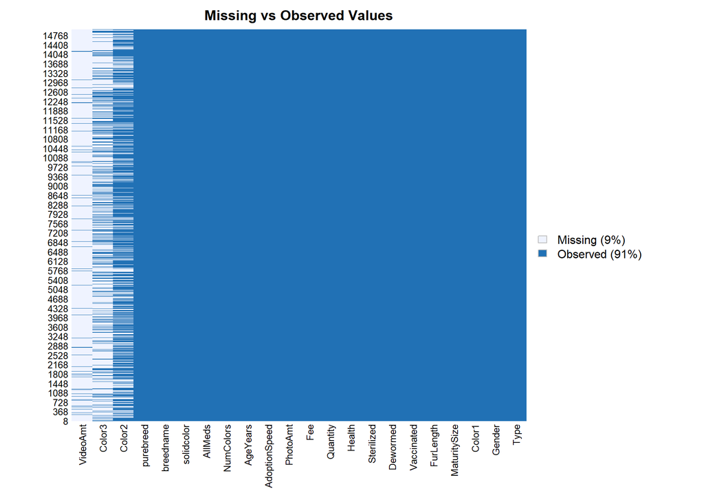

```r
missmap(data, main = "Missing vs Observed Values")
```

After making this visualization, it is best to remove the variables `VideoAmt`, `ColorName2`, and `ColorName3`.

```r
#make copy
train_data <- data
#remove NA
train_data <-train_data %>%
  dplyr::select(-c(VideoAmt,Color2,Color3))
train_data <- na.omit(train_data)
```

```r
map(train_data, ~sum(is.na(.))) %>% t()
```

```
##      Type Gender Color1 MaturitySize FurLength Vaccinated Dewormed Sterilized
## [1,] 0    0      0      0            0         0          0        0
##      Health Quantity Fee PhotoAmt AdoptionSpeed breedname AgeYears NumColors
## [1,] 0      0        0   0        0             0         0        0
##      AllMeds purebreed solidcolor
## [1,] 0       0         0
```

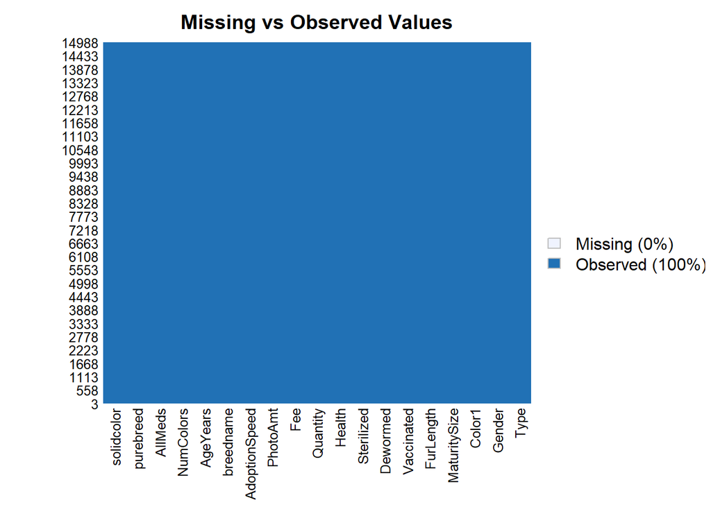

```r
missmap(train_data, main = "Missing vs Observed Values")
```

### Dog Breed Word Cloud

Below we use `wordcloud` to visualize the dog breeds in our data. Note the Mixed Breed has been removed as it was skewing our data with the highest number of observations with 5923 total.

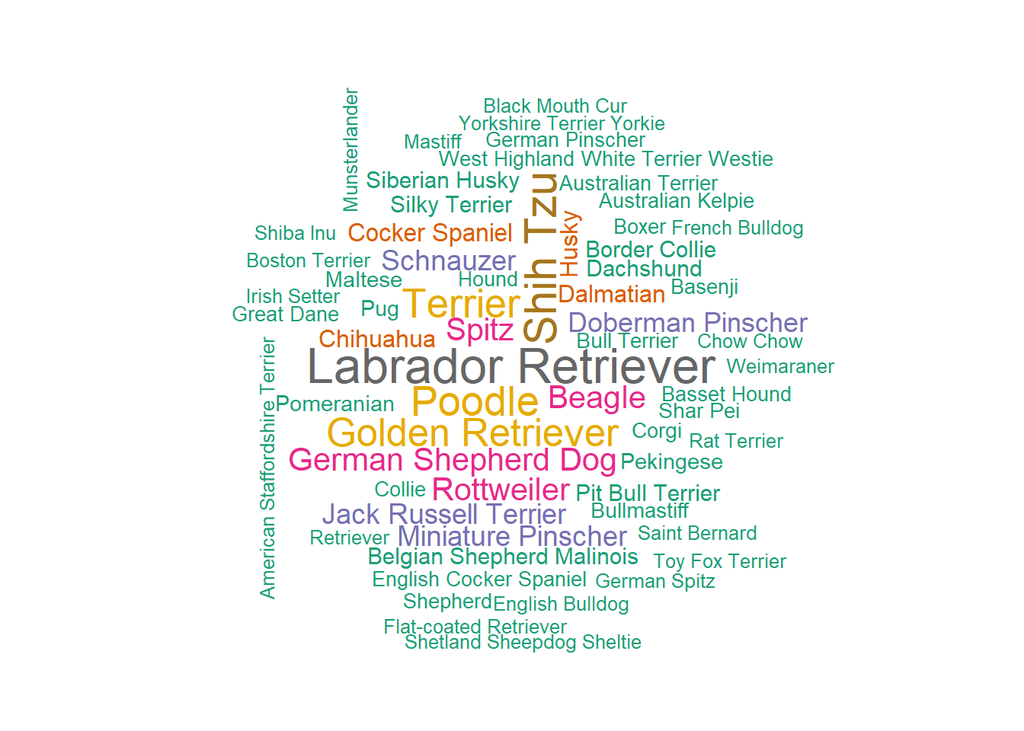

```r
set.seed(123)
dogs <- train_data %>%
  filter(Type== "Dog")

wordtable <- table(dogs$breedname) %>%
  as.data.frame() %>%
  filter(Freq >0) %>%
  arrange(desc(Freq)) %>%
  slice(c(-1))

wordcloud(words = wordtable$Var1, freq = wordtable$Freq,
          max.words=250,random.order=FALSE, scale=c(2,.8),
          rot.per=0.1, colors=brewer.pal(8, "Dark2"))
```

### Cat Breed Word Cloud

Below we use `wordcloud` to visualize the cat breeds in our data.

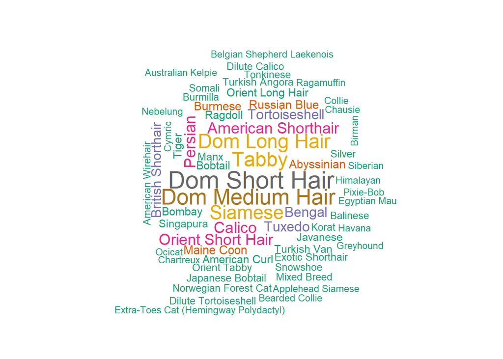

```r
set.seed(456)
cats <- train_data %>%
  filter(Type== "Cat")

wordtable2 <- table(cats$breedname) %>%
  as.data.frame() %>%
  filter(Freq >0) %>%
  arrange(desc(Freq))

wordcloud(words = wordtable2$Var1, freq = wordtable$Freq,
          max.words=250,random.order=FALSE, scale=c(2,.8),
          rot.per=0.1, colors=brewer.pal(8, "Dark2"))
```